# Practical Machine Learning Course Project

Mark Dakkak

April 23, 2015

## Introduction

Using devices such as *Jawbone Up*, *Nike FuelBand*, and *Fitbit* it is now possible to collect a large amount of data about personal activity inexpensively. These type of devices are part of the quantified self movement - a group of enthusiasts who take measurements about themselves to improve their health, to find patterns in their behavior, or because they are tech geeks.

One this that people regularly do is quantify how *much* of a particular activity they do, but they rarely quantify *how well they do it*. Six participants were asked to perform barbell lifts correctly and incorrectly in 5 different ways. The goal of this project is to use data from accelerometers on the belt, forearm, arm, and dumbell of these participants to correctly classify the type of barbell lift.

## Data

The data used for this project is available from [this website](http://groupware.les.inf.puc-rio.br/har) in the **Weight Lifting Exercise Dataset**. Six young healthy participants were asked to perform one set of 10 repititions of the Unilateral Dumbbell Biceps Curl in five different fashions: exactly according to the specification (Class A), throwing the elbows to the front (Class B), lifting the dumbbell only halfway (Class C), lowering the dumbbell only halfway (Class D) and throwing the hips to the front (Class E).

Class A corresponds to the specified execution of the exercise, while the other 4 classes correspond to common mistakes. Participants were supervised by an experienced weight lifter to make sure the execution complied to the mannyer they were supposed to simulate. The exercises were performed by six male participants aged between 20-28 years, with little weight lifting experience. We made sure that all participants could easily simulate the mistakes in a safe and controlled manner by using a relatively light dumbbell (1.25 kg).

## Data Manipulation

### Step 1: Set up the environment

The analysis below requires the following packages:

```r
library(data.table)
library(caret)
```

```r
library(ggplot2)
library(rattle)
library(rpart)
library(rpart.plot)
```

Note that I use data.table version 1.9.5, which enables reading files from “https” URLS. To download this version of the package, follow [these](https://github.com/Rdatatable/data.table/wiki/Installation) instructions.

### Step 2: Load data

To load the data directly into memory:

```r
training <- fread("https://d396qusza40orc.cloudfront.net/predmachlearn/pml-training.csv")
testing <- fread("https://d396qusza40orc.cloudfront.net/predmachlearn/pml-testing.csv")
```

### Step 3: Clean data

#### Missing variables

First, look at how many missing values are in each column. To do this, I calculate the number of NAs and empty strings.

```r
missing_training <- as.data.table(t(training[, lapply(.SD, function(x) sum(is.na(x) | x == "", na.rm = TRUE))]), keep.rownames = TRUE)
table(missing_training$V1)
```

```
##
##     0 19216
##    60   100
```

```r
missing <- missing_training[V1 != 0, rn]
training <- training[, setdiff(names(training), missing), with = FALSE]
testing <- testing[, setdiff(names(testing), missing), with = FALSE]
```

#### Split training and validation

First, I convert back to data frames, which work seamlessly with the caret syntax:

```r
training <- as.data.frame(training)
testing <- as.data.frame(testing)
```

And then split the training into train (70%) and validate (30%) subsets:

```r
inTrain <- createDataPartition(y = training$classe, p = 0.7, list = FALSE)
train <- training[inTrain,]
validate <- training[-inTrain,]
```

Now, the dimensions of the training set are (13737, 60) and the dimensions of the validation set are (5885, 60).

#### Variables with zero / near-zero variance

Next, I identify the variables with zero or near-zero variance:

```r
nsv <- nearZeroVar(train, saveMetrics = TRUE)
nsv <- nsv[order(-nsv$freqRatio),]
head(nsv)
```

```
##               freqRatio percentUnique zeroVar   nzv
## pitch_arm         88.19      20.39019   FALSE FALSE
## pitch_forearm     67.65      19.00706   FALSE FALSE
## roll_arm          48.57      17.52930   FALSE FALSE
## new_window        44.94       0.01456   FALSE  TRUE
## yaw_arm           30.13      19.11626   FALSE FALSE
## yaw_forearm       15.20      12.78299   FALSE FALSE
```

Variables with near zero variance can be thrown out of the prediction algorithm, because they contribute very little to determining the outcome. In the table above, we can see that the single most common value for the variable “new_window” occurs nearly 50 times more often than the second most common value. As it turns out, there are no variables with zero variance and “new_window” is the only variable identified as having near zero variance:

```r
sum(nsv$zeroVar)
```

```
## [1] 0
```

```r
sum(nsv$nzv)
```

```
## [1] 1
```

I remove this variable from the dataset:

```r
train <- train[,setdiff(names(train),"new_window")]
validate <- validate[,setdiff(names(validate), "new_window")]
testing <- testing[,setdiff(names(testing), "new_window")]
```

#### Remove unrelated variables

I removed the variables V1 (captures the order of observations), “user_name” (captures the individual’s name), window and the timestamp values. These variables do not contribute to accelerometer readings, which are the focus of this project.

```r
train <- train[, setdiff(names(train), c(grep("time|window", names(train), value = TRUE), "V1", "user_name"))]
validate <- validate[, setdiff(names(validate), c(grep("time|window", names(validate), value = TRUE), "V1", "user_name"))]
testing <- testing[, setdiff(names(testing), c(grep("time|window", names(testing), value = TRUE), "V1", "user_name"))]
```

Now, we are left with 52 predictor variables.

#### Fix class of outcome

The last data cleaning step is to ensure that the activity “classe” is a factor variable:

```r
train$classe <- as.factor(train$classe)
validate$classe <- as.factor(validate$classe)
```

## Data Modeling

My goal going into this project is to achieve an out-of-sample accuracy of 80%, meaning that the machine learning model correctly classifies 80% of the movements in the test data. I will develop the model on the training subset, validate it on the validate subset, and test it on 20 unseen cases.

### Step 1: Classification and regression tree

First, I develop the classification model on the trianing data:

```r
treeModel <- rpart(classe ~ ., data = train, method = "class")
```

Below is a fancy plot of the classification tree:

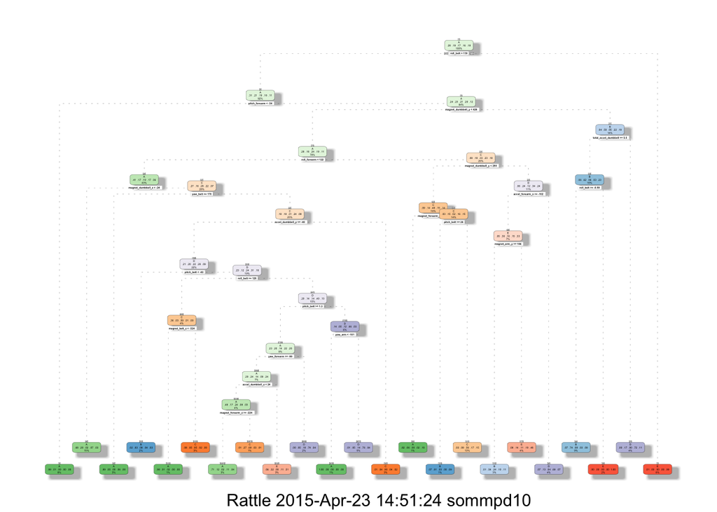

```r
fancyRpartPlot(treeModel)
```

#### Validate

First, we validate the model on the subset of training data that we haven’t seen yet:

```r
predictTree <- predict(treeModel, validate, type = "class")
confusionMatrix(predictTree, validate$classe)
```

```
## Confusion Matrix and Statistics
##
##           Reference
## Prediction    A    B    C    D    E
##          A 1527  220   32  106   38
##          B   53  619   84   49   82
##          C   48  110  821  146  124
##          D   18   78   63  605   62
##          E   28  112   26   58  776
##
## Overall Statistics
##
##                Accuracy : 0.739
##                  95% CI : (0.727, 0.75)
##     No Information Rate : 0.284
##     P-Value [Acc > NIR] : <2e-16
##
##                   Kappa : 0.668
##  Mcnemar's Test P-Value : <2e-16
##
## Statistics by Class:
##
##                      Class: A Class: B Class: C Class: D Class: E
## Sensitivity             0.912    0.543    0.800    0.628    0.717
## Specificity             0.906    0.944    0.912    0.955    0.953
## Pos Pred Value          0.794    0.698    0.657    0.732    0.776
## Neg Pred Value          0.963    0.896    0.956    0.929    0.937
## Prevalence              0.284    0.194    0.174    0.164    0.184
## Detection Rate          0.259    0.105    0.140    0.103    0.132
## Detection Prevalence    0.327    0.151    0.212    0.140    0.170
## Balanced Accuracy       0.909    0.743    0.856    0.791    0.835
```

In the confusion matrix output we see that the classification tree does much better predicting Class A movements than Class B movements. We can hone in on the accuracy measures of interest:

```r
accuracyTree <- postResample(predictTree, validate$classe)
accuracyTree
```

```
## Accuracy    Kappa
##   0.7388   0.6680
```

We see that the classification and regression tree correctly classified 74% of the movements. The kappa statistic measures inter-rater agreement for categorical items and is generally thought to be a more robust measure than simple percent agreement calculation, because $\kappa$ takes into account the agreement occurring by chance.

Lastly, the out-of-sample estimated accuracy is calculated:

```r
ooseTree <- (1-as.numeric(confusionMatrix(validate$classe, predictTree)$overall[1]))
ooseTree
```

```
## [1] 0.2612
```

Thus, we estimate that about a quarter of movements will be misclassified by the model.

#### Test

Now, we run the 20 test cases through the classification and regression tree:

```r
resultTree <- predict(treeModel, testing[, setdiff(names(testing), c("problem_id"))], type = "class")
resultTree
```

```
##  1  2  3  4  5  6  7  8  9 10 11 12 13 14 15 16 17 18 19 20
##  B  A  B  A  A  C  D  A  A  A  C  B  C  A  E  E  A  A  A  B
## Levels: A B C D E
```

We expect ~75% of these predictions to be correct.

### Step 2: Random forest

First, I develop the random forest model on the training data, where I draw 250 boostrap samples (ntree) from the original data and use 5-fold cross validation:

```r
controlRF <- trainControl(method = "cv", 5)
modelRF <- train(classe ~ ., data = train, method = "rf", trControl = controlRF, ntree = 250)
modelRF
```

```
## Random Forest
##
## 13737 samples
##    52 predictor
##     5 classes: 'A', 'B', 'C', 'D', 'E'
##
## No pre-processing
## Resampling: Cross-Validated (5 fold)
##
## Summary of sample sizes: 10990, 10989, 10990, 10988, 10991
##
## Resampling results across tuning parameters:
##
##   mtry  Accuracy  Kappa   Accuracy SD  Kappa SD
##    2    0.9914    0.9891  0.002084     0.002637
##   27    0.9912    0.9889  0.002220     0.002808
##   52    0.9831    0.9786  0.003321     0.004205
##
## Accuracy was used to select the optimal model using  the largest value.
## The final value used for the model was mtry = 2.
```

#### Validate

Now, we run the random forest model on the validation set:

```r
predictRF <- predict(modelRF, validate)
confusionMatrix(validate$classe, predictRF)
```

```
## Confusion Matrix and Statistics
##
##           Reference
## Prediction    A    B    C    D    E
##          A 1674    0    0    0    0
##          B    4 1135    0    0    0
##          C    0    6 1020    0    0
##          D    0    0   19  945    0
##          E    0    0    0    1 1081
##
## Overall Statistics
##
##                Accuracy : 0.995
##                  95% CI : (0.993, 0.997)
##     No Information Rate : 0.285
##     P-Value [Acc > NIR] : <2e-16
##
##                   Kappa : 0.994
##  Mcnemar's Test P-Value : NA
##
## Statistics by Class:
##
##                      Class: A Class: B Class: C Class: D Class: E
## Sensitivity             0.998    0.995    0.982    0.999    1.000
## Specificity             1.000    0.999    0.999    0.996    1.000
## Pos Pred Value          1.000    0.996    0.994    0.980    0.999
## Neg Pred Value          0.999    0.999    0.996    1.000    1.000
## Prevalence              0.285    0.194    0.177    0.161    0.184
## Detection Rate          0.284    0.193    0.173    0.161    0.184
## Detection Prevalence    0.284    0.194    0.174    0.164    0.184
## Balanced Accuracy       0.999    0.997    0.990    0.998    1.000
```

From the confusion matrix, we can already tell the random forest model outperforms the classification tree. For each class of movement, the sensitivity and specificity are > 98%. We can hone in on the accuracy measures of interest:

```r
accuracy <- postResample(predictRF, validate$classe)
accuracy
```

```
## Accuracy    Kappa
##   0.9949   0.9936
```

The random forest model achieves an accuracy of 99.5%, much higher than the accuracy of the classification tree.

Lastly, the estimated out of sample accuracy is:

```r
oose <- (1-as.numeric(confusionMatrix(validate$classe, predictRF)$overall[1]))
oose
```

```
## [1] 0.005098
```

For random forest, we expect 0.5% of movements to be misclassified.

#### Test

Now, we run the 20 test cases through thr random forest model:

```r
resultRF <- predict(modelRF, testing[, setdiff(names(testing), c("problem_id"))])
resultRF
```

```
##  [1] B A B A A E D B A A B C B A E E A B B B
## Levels: A B C D E
```

We expect nearly all of these predictions to be correct.